# グラフのスペクトル解析

元ネタは[Spectral methods for analyzing and visualizing networks: an introduction](http://citeseerx.ist.psu.edu/viewdoc/summary?doi=10.1.1.84.3718)

元ネタPDFには、少し記載に誤りがあったりするので注意すること

## Abstract

### グラフのスペクトル解析が明らかにすること概論

グラフ（ネットワーク）のスペクトル解析（固有値分解ベースの解析）が明らかにするグラフの特徴には以下のようなものがある

- 固有値からわかること
- 直径
- クラスタ（凝集）の存在
- 長いパス
- ボトルネック
- グラフのランダムな程度
- 固有ベクトルからわかること
- グラフを視覚化するときの軸の選択
- クラスタ検出
- その他の特徴の検出
- 固有値・固有ベクトル以外の情報（ノード次数など）と組み併せて、得られる特徴
- ロバストネスの程度(ノードや接続の除去に対する連結性が維持されやすいかいなか)
- その他の構造特徴

### 本文書が扱うスペクトル解析の概要

３タイプのスペクトル解析

- 隣接行列
- ラプラシアン
- Normal 行列

## イントロダクション

この文書では、自己ループのない、連結無向グラフで、エッジの重みはすべて１であるものを対象として記載するが、エッジに重みがある場合にも当てはまることが多い

### この文書での記法

- 隣接行列 A
- 次数行列 D: 対角成分が頂点次数であるような対角グラフ
- ノード数(グラフのオーダー) |V|
- ラプラシアン L = D-A
- Normal行列 $N = D^{-1}A$

## 隣接行列Aのスペクトル

### 特徴量の近似

行列のべき乗の計算は大きすぎない行列ならば現在の計算機能力をもってすれば比較的容易であるし、グラフの直径を計算する高速に動く関数もあるが、直径の正確な計算が困難なグラフがあったとする

そのようなとき、k-regular グラフの直径のupper boundが以下のように、２番目に大きい固有値$\lambda_2$を用いて推定できる

$$Diam(G) \le \lceil \ln{|V|-1}/\ln(k/\lambda_2) \rceil$$

ただし、k-regular グラフとは、すべてのノードの次数がkであるようなグラフのことである

これは、スペクトルにより、直径のようなグラフの重要な特徴の情報が得られることの例である。

次数が大きいほど直径は短く、$\lambda_2$が小さいほど直径は短くなることが式から読み取れる

regularグラフに限らない、一般的なグラフにおいても、スペクトルを用いて直径のupper boundを推定する方法が知られているが、ここでは触れない。

隣接行列のべき乗は以下のように、固有値・固有ベクトルごとに計算した項の加算として計算できる

$$A^k = \sum_{i=1}^{|V|} \lambda_i a_i a_i^T$$
ただし、$\lambda$は固有値、$a$は固有ベクトルであり、$a a^T$は$|V| \times |V|$行列となる

```r
library(igraph)
# 行列のべき乗計算
my.matpower.simple <- function(A,k){
    eigenout <- eigen(A)
    V <- eigenout[[2]]
    ev <- eigenout[[1]]
    sign.ev <- sign(ev)
    abs.ev <- abs(ev)
    log.diag <- log(abs.ev) * k
    sign.pow <- sign.ev^k

    true.diag <- sign.pow * exp(log.diag)
    V %*% diag(true.diag) %*% solve(V)
}
# ランダムに隣接行列を作る
my.rAdjacency <- function(n,prob=c(0.8,0.2)){
    A <- matrix(sample(0:1,n^2,replace=TRUE,prob=prob),n,n)
    A <- A + t(A)
    diag(A) <- 0
    A[which(A>0)] <- 1
    return(A)
}

my.matpower.simple2 <- function(A,k){
  eigen.out <- eigen(A)
  ret <- matrix(0,length(A[1,]),length(A[,1]))
  for(i in 1:length(ret[1,])){
    tmp <- eigen.out[[2]][,i]
    ret <- ret + eigen.out[[1]][i]^k * matrix(tmp,ncol=1) %*% matrix(tmp,nrow=1)
  }
  return(ret)
}
```

```r
n <- 1000
A <- my.rAdjacency(n,prob=c(0.9,0.1))
# 連結グラフとは限らないので、連結になるようにちょっと工夫をする
A. <- diag(rep(1,n))
A. <- A.[c(2:n,1),]
A <- A + A. + t(A.)
A[which(A>0)] <- 1

g <- graph.adjacency(A)
diam <- diameter(g)
diam # グラフ直径
```

```
## [1] 2
```

```r
A.diam <- my.matpower.simple(A,diam)
range(A.diam) # 0がない
```

```
## [1]  11 227
```

#### 補足

- どんなグラフでも$A^N$の成分がすべて正整数になるか、というと、そうとは限らない。歩き方の場合には歩数の偶奇が影響するからである。念のため、この節の末尾に例を挙げておく

```r
A <- rbind(c(0,1,0),c(1,0,1),c(0,1,0))
A
```

```
##      [,1] [,2] [,3]
## [1,]    0    1    0
## [2,]    1    0    1
## [3,]    0    1    0
```

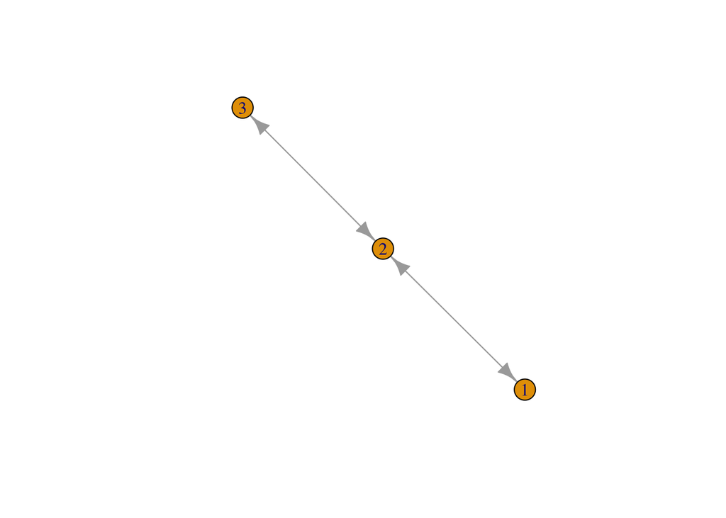

```r
g <- graph.adjacency(A)
plot(g)
```

```r
A %*% A
```

```
##      [,1] [,2] [,3]
## [1,]    1    0    1
## [2,]    0    2    0
## [3,]    1    0    1
```

```r
A %*% A %*% A
```

```
##      [,1] [,2] [,3]
## [1,]    0    2    0
## [2,]    2    0    2
## [3,]    0    2    0
```

```r
round(my.matpower.simple(A,0))
```

```
##      [,1] [,2] [,3]
## [1,]    1    0    0
## [2,]    0    1    0
## [3,]    0    0    1
```

```r
round(my.matpower.simple(A,1))
```

```
##      [,1] [,2] [,3]
## [1,]    0    1    0
## [2,]    1    0    1
## [3,]    0    1    0
```

```r
round(my.matpower.simple(A,2))
```

```
##      [,1] [,2] [,3]
## [1,]    1    0    1
## [2,]    0    2    0
## [3,]    1    0    1
```

```r
round(my.matpower.simple(A,3))
```

```
##      [,1] [,2] [,3]
## [1,]    0    2    0
## [2,]    2    0    2
## [3,]    0    2    0
```

```r
round(my.matpower.simple(A,4))
```

```
##      [,1] [,2] [,3]
## [1,]    2    0    2
## [2,]    0    4    0
## [3,]    2    0    2
```

```r
round(my.matpower.simple2(A,4))
```

```
##      [,1] [,2] [,3]
## [1,]    2    0    2
## [2,]    0    4    0
## [3,]    2    0    2
```

### 平衡状態に達する

Aのべき乗を上げていくと、すべての列ベクトルが係数倍の違いのみで同じベクトルになる

歩数を増やすにつれ、「どこを始点にしていたのかを忘れ」る結果であると解釈することもできる

また、グラフ上を粒子がランダムに移動すると平衡状態に達することを意味している

これを利用すると、適当なベクトルにAを作用することを繰り返し、ベクトルの変化が定数倍のみの状態に達せしめる。そのときのベクトルが最大固有値に対応する固有ベクトル$a_1$であり、固有値は、Aの作用による定数倍変化の係数となる

この方法をさらに応用して、大きい順に固有値と固有ベクトルを求めていくこともできる

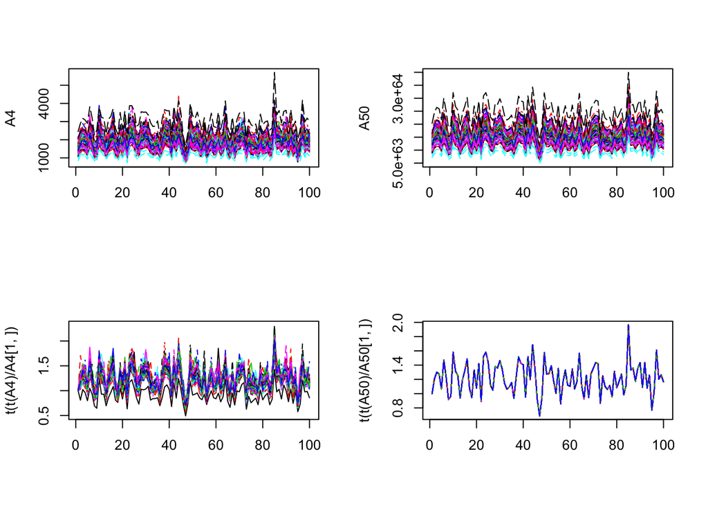

```r
n <- 100
A <- my.rAdjacency(n,prob=c(0.9,0.1))
# 連結グラフとは限らないので、連結になるようにちょっと工夫をする
A. <- diag(rep(1,n))
A. <- A.[c(2:n,1),]
A <- A + A. + t(A.)
A[which(A>0)] <- 1

par(mfcol=c(2,2))
my.matpower.simple(A,4) -> A4
my.matpower.simple(A,50) -> A50
matplot(A4,type="l")
matplot(t(t(A4)/A4[1,]),type="l")
matplot(A50,type="l")
matplot(t(t(A50)/A50[1,]),type="l")
```

```r
par(mfcol=c(1,2))
```

### k歩の歩き方の個数

$A^k$の(i,j)成分の値は、k歩でノードiからノードjへ到達する歩き方の場合の数であることが知られている。

ノードのi,jを区別しているとき、ノードの順序を変えると、値が変わってしまうが、値の分布は変わらない。

従って、$A^k$の値の分布は、ノードi,jのラベルのつけ方に依存しない「不変量」である

不変量ではあるが、「分布」なので、少し使いにくい。

普通にグラフの不変量と言うときには、ノードラベルの付け替えをしても変わらないスカラー量のことを指すのが普通である。

たとえば$A^k$のセルの値の和、というのは、値分布から得られる不変スカラー量である。

また、$A^k$のトレースも、ラベルのつけ方に寄らないスカラー量である。

```r
eigenout <- eigen(A)
sum(eigenout[[1]]) # 0になる
```

```
## [1] -9.048318e-14
```

$Tr(A) = \sum_{i=1}^{|V|} \lambda_i = 0$は、グラフにセルフループエッジがないことを意味している。

また、 $Tr(A^0) = Tr(I) = \sum_{i=1}^{|V|} 1 = |V|$ により、$A^0$からはノード数がわかる。

$A^2$ は２歩で行きつける歩き方に関する情報である。 自身から自身へと２歩で行きつける歩き方は各ノードのエッジ数になるから、$Tr(A^2)$はエッジ数の２倍となる。

ちなみに$A$の要素の和はエッジの本数の２倍であるから、$A$からも計算できる

```r
sum(diag(A%*%A)) # エッジの本数の２倍
```

```
## [1] 2046
```

```r
sum(A)
```

```
## [1] 2046
```

以下の関係を使うと
$$0^2 = (\lambda_1 + ... + \lambda_{|V|})^2 = \sum_{i=1}^{|V|} \lambda_i^2 - 2\sum_{i \ne j} \lambda_i \lambda_j$$
$2\sum_{i \ne j} \lambda_i \lambda_j = \sum_{i=1}^{|V|} \lambda_i^2 - (\sum_{i=1}^{|V| \lambda_i})^2$と計算できる

```r
sum(eigenout[[1]]^2) -(sum(eigenout[[1]]))^2
```

```
## [1] 2046
```

$A^3$が持つ情報は、３歩で行きつける歩き方の情報である。自身に３歩で戻ってくるのは三角形であるから、三角形の個数は、$Tr(A^3)$となる。

固有値のトリオの総和 $_{i\ne j, \ne k}\lambda_i \lambda_j \lambda_k$のような値も、

$A^3$を計算する代わりに、上で使った式
$$0^2 = (\lambda_1 + ... + \lambda_{|V|})^2 = \sum_{i=1}^{|V|} \lambda_i^2 - 2\sum_{i \ne j} \lambda_i \lambda_j$$
を拡張する方式で計算することができる。

これは $m\times m$対称行列の固有値$\lambda$が、次の特性多項式の根であることと関係する

$$x^m + c_1 x^{m-1} + ... + c_{m-1} x + c_{m} = \prod_{i=1}^m (x-\lambda_i) = 0$$

$$c_1 = \sum_{i=1}^m \lambda_i　\\
c_2 = \sum_{i \ne j}^m \lambda_i \lambda_j \\
c_3 = \sum_{i \ne j \ne k}^m \lambda_i \lambda_j \lambda_k\\
...$$

### まとめ

隣接行列（とそのべき乗）が持つ情報はサイクルや直径に関するものであると言える

その値が自然数であることを、小さなグラフを使って確認しておく

```r
n <- 10
A <- my.rAdjacency(n,prob=c(0.7,0.3))
eigen.out <- eigen(A)
eigen.out[[1]]
```

```
##  [1]  4.8353991  1.6450763  1.3289740  0.7372314 -0.3706813 -0.4149055
##  [7] -0.9168137 -1.6354819 -2.2786172 -2.9301811
```

```r
library(gtools)
ans <- rep(0,n)
for(i in 1:n){
  cmb <- combinations(n,i)
  for(j in 1:length(cmb[,1])){
    ans[i] <- ans[i] + prod(eigen.out[[1]][cmb[j,]])
  }
}
round(ans,5)
```

```
##  [1]    0  -23   26   98 -124 -127  166   24  -56   12
```

## ラプラシアン行列Lのスペクトル

### エネルギー状態の低いノードの配置方法

$|V|$個のノードが隣接行列$A=(a_{ij})$であらわされるエッジで互いに結びついているときに、ノードを配置して、その配位エネルギー
$$z = \frac{1}{2} \sum_{i,j} (x_i-x_j)^2 a_{ij}$$
が最小になるように位置を決める問題を解くことにする。

zの式を変形すると
$$z = \sum_{i}x_i^2 \sum_{j}a_{ij} - \sum_{i \ne j} x_i x_j a_{ij}\\
=\sum_{i}x_i^2 k_i - \sum_{i \ne j} x_i x_j a_{ij}$$
ただし、$k_i$はノードiの次数、となるので 結局、ノードの次数を対角成分とする行列$D$を用いて
$$z = X^T(D-A)X = X^T L X$$
を得る

### ラグランジュの未定乗数法

このzの最小化にあたって、 $X=(x_1,...)$をどこにおいてもよいのでは、全部を0にするとか、同じ相対配置で平行移動しても$z$の値が変わらないことなどから、特定の位置を決められないので、$X^TX=1$という制約を入れることにする。 こうすることで、すべてのノードが１点に集中した場合は排除され、平行移動の問題も解決する。

制約条件付き最適問題には、ラグランジュの未定乗数法を用いて
$$f(\lambda)=z - \lambda X^TX = X^T L X - \lambda X^T X$$
を最小化する$\lambda$を探せばよぃ。

最小値をもたらす$\lambda$は微分して0になるような場合に含まれるから、Xに関して微分して

$$\frac{ d f(\lambda)}{dX} = LX - \lambda X = 0$$
を解くことになる。

これは、$L$の固有値と固有ベクトルを求める問題となっている。

ただし、$\lambda = 0$, $X=(1,1,...)$というつまらない解(trivial eigenvalue/eigenvector)がある。これはすべてのノードを同じ位置に置くというもので、配置としてつまらない。

Rでやってみる

まず、Lを計算し、

```r
D <- diag(apply(A,1,sum))
L <- D - A
# lambda = 0, X = 1\sqrt(|V|) * (1,1,...)がつまらない解になっていることの確認
trivial.X <- 1/sqrt(length(A[,1])) * rep(1,length(A[,1]))
range(L %*% trivial.X) # すべての要素が0
```

```
## [1] -3.330669e-16  1.110223e-16
```

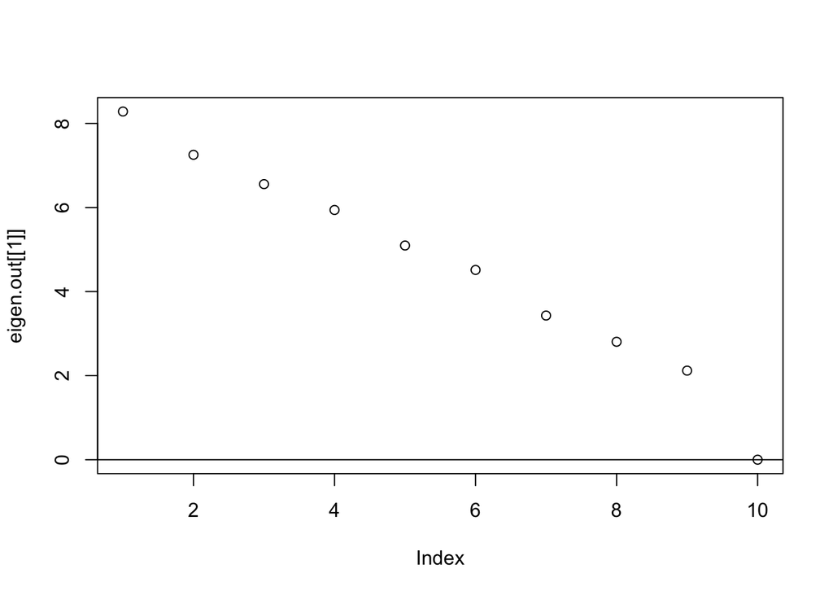

```r
eigen.out <- eigen(L)
plot(eigen.out[[1]])
abline(h=0)
```

すべての固有ベクトルが$X^TX = 1$を満足していることも念のために確認する

```r
range(diag(t(eigen.out[[2]]) %*% eigen.out[[2]]))
```

```
## [1] 1 1
```

固有値が小さい順にzの値がどのような値になっているかを計算してみる

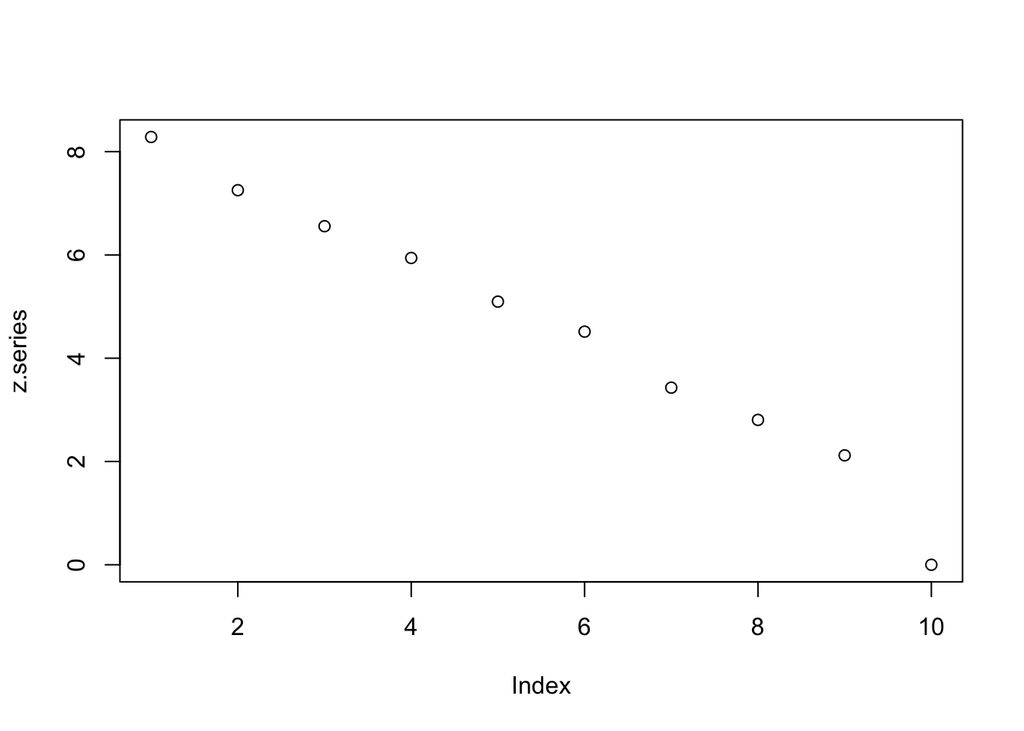

```r
z.series <- rep(0,length(eigen.out[[1]]))
for(i in 1:length(z.series)){
  tmp <- eigen.out[[2]][,i]
  z.series[i] <- matrix(tmp,nrow=1) %*% L %*% matrix(tmp,ncol=1)
}
plot(z.series)
```

$\lambda$に一致する値となる。

したがって、すべてのノードを同じ場所に置くのではないという条件で、zを最小化するのは、0以外で最も小さい固有値・固有ベクトルによって示されることがわかる

ラプラシアンのグラフにおける意味は、空間等における物理学のラプラシアンの意味として考えることができる。

物理学でのラプラシアンは関数の勾配の発散を表し、ポテンシャル、拡散、波の伝搬、量子力学の固有状態などを説明する

### 特性方程式

Lの固有値についても特性方程式がある

$$x^m + c_1 x^{m-1} + ... + c_{m-1} x + c_{m} = \prod_{i=1}^m (x-\lambda_i) = 0$$

$$c_1 = \sum_{i=1}^m \lambda_i　\\
c_2 = \sum_{i \ne j}^m \lambda_i \lambda_j \\
c_3 = \sum_{i \ne j \ne k}^m \lambda_i \lambda_j \lambda_k\\
...$$

$c_1 = Tr(L)$はエッジの数の２倍である。

$c_{m=|V|} = 0$は、最小固有値0に対応するものである。これはすべての固有値の積であるから、固有値の中に値が0のものが存在するので、この値も0になる

### 全域木の数

$c_{m-1}$は、m個の固有値から、m-1個を取ったものの積の和であるが、値が0の固有値を含む項の値は0となるから、結局この値は、0でない固有値の積になる。 この値は、全域木の数になることが知られている

$c_{m-1}$以外も、値が0の固有値の項を除いた組み合わせで生じる値になっており、それは木構造と関係している（らしい）

### 連結成分の数

連結グラフのラプラシアンには値が0の固有値があった。

じつは、ラプラシアンの値0の固有値の数は連結成分数となっている

エッジ本数を抑えた小さめのグラフを作り、連結成分を複数にして、ラプラシアンの固有値を調べてみる

```r
n <- 20
A <- my.rAdjacency(n,prob=c(0.95,0.05))
D <- diag(apply(A,1,sum))
L <- D - A
eigen.out <- eigen(L)
round(eigen.out[[1]],10)
```

```
##  [1] 5.0861302 4.8136065 4.4142136 3.4142136 3.0000000 2.5293166 2.4280067
##  [8] 2.0000000 1.5857864 1.0000000 0.6570769 0.5857864 0.4858631 0.0000000
## [15] 0.0000000 0.0000000 0.0000000 0.0000000 0.0000000 0.0000000
```

```r
length(which(abs(eigen.out[[1]]) < 10^(-10))) # ほとんどゼロのものを数える
```

```
## [1] 7
```

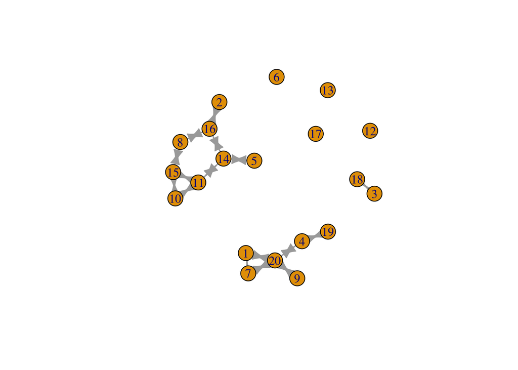

```r
g <- graph.adjacency(A)
plot(g)
```

### 直径

直径の上界に以下が知られている。非0の小さい固有値$\lambda_1$が小さいほど（0に近いほど）、グラフの連結成分は増える方向に向かうので、それは直径が長くなる方向に向かうことという解釈が成り立つ

$$Diam(G) \lceil \cosh^{-1}{(|V|-1)}/\cosh^{-1}{((\lambda_{m-1} + \lambda_1)/(\lambda_{m-1}-\lambda_1))}\rceil$$

### まとめ

ラプラシアン行列（とそのべき乗）が持つ情報は木構造の数に関する情報を有する

グラフが大きすぎるとこの値が自然数になるかどうかわからないので、小さいグラフを作り直して調べてみる

確かに、固有値は整数ではないが、特性方程式の係数は自然数になっている。

```r
n <- 7
A <- my.rAdjacency(n,prob=c(0.7,0.3))
D <- diag(apply(A,1,sum))
L <- D - A
eigen.out <- eigen(L)
prod(eigen.out[[1]][-length(eigen.out[[1]])])
```

```
## [1] 2240
```

```r
eigen.out[[1]]
```

```
## [1] 6.561553e+00 5.000000e+00 4.414214e+00 4.000000e+00 2.438447e+00
## [6] 1.585786e+00 6.217249e-15
```

```r
ans <- rep(0,n)
for(i in 1:n){
  cmb <- combinations(n,i)
  for(j in 1:length(cmb[,1])){
    ans[i] <- ans[i] + prod(eigen.out[[1]][cmb[j,]])
  }
}
round(ans,5)
```

```
## [1]   24  232 1152 3083 4188 2240    0
```

## Normal行列Nのスペクトル

### Normal 行列

Normal行列Nのスペクトルは、ラプラシアンのときのそれと似ている川かねて。

ラプラシアンのときには、$X^TLX$の最小化にあたり、制約項を$X^TX=1$の制約項を用いた。

Normal行列Nの場合は、$X^TX=1$の代わりに$X^TDX=1$と制約する。

これにより、解くべき式は
$$LX = \mu DX$$

となる。

Dに逆行列があるとすれば(連結グラフの場合には、$D^{-0.5}$も存在する)

$$D^{-1}LX = D^{-1}(D-A)X = (I - D^{-1}A)X = \mu X$$

これを少し変形して

$$NX = \nu X$$
ただし、Normal行列として$N=D^{-1}A$ と書き、固有値は$\nu = 1-\mu$とすることで

固有値・固有ベクトルの算出式を$NX = \nu X$とする

### Normal 行列の特徴

- ラプラシアンの一般化版とみなせる(orthogonalityの定義を変えたもの)
- つまらない(trivial)固有値($\nu_0=1$)と固有ベクトル($n_0$)がある
- 固有値の値に一定の範囲がある：$1 = \nu_0 \ge \nu_1 \ge ... \ge \nu_{|V|-1} \ge -1$
- $N$の行和は1である。つまり$N$は確率推移行列の性質を持つ
- 値が1の固有値の数は連結成分数である
- -1の固有値はbipartiteグラフのときにのみ観察される。Bipartiteグラフの固有値は、絶対値が同じで符号の異なる固有値のペアとなる

計算上の特徴としては次のものがある

- $N$自体は対称行列ではない。したがって隣接行列・ラプラシアンの際に対称性を利用した計算を転用できない
- しかしながら、固有値のみを得るためであれば、$N=D^{-1}A$の固有値と$D^{-1/2}AD^{-1/2}$の固有値が同じであることから、対称である$D^{-1/2}AD^{-1/2}$を代用として用いるという方法もある。$D^{-1/2}e_i = n_i$というような、対応する固有ベクトルの計算法もある

RでNの確認をしておく

```r
n <- 500
A <- my.rAdjacency(n,prob=c(0.96,0.04))
D <- diag(apply(A,1,sum))
D.half <- diag(sqrt(apply(A,1,sum)))
N <- solve(D) %*% A
# Nは非対称
range(N-t(N))
```

```
## [1] -0.02504638  0.02504638
```

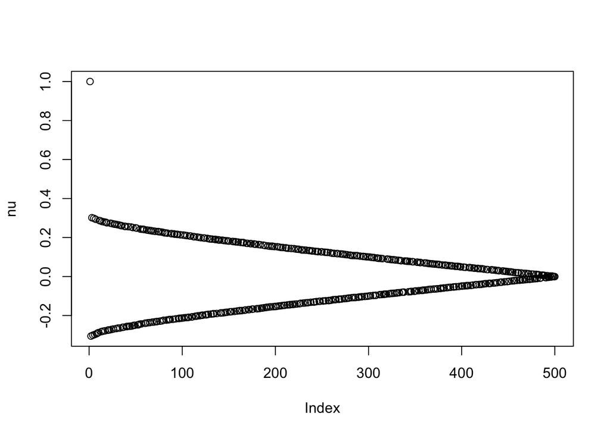

```r
eigen.out <- eigen(N)
nu <- eigen.out[[1]]
nu.ev <- eigen.out[[2]]
plot(nu)
```

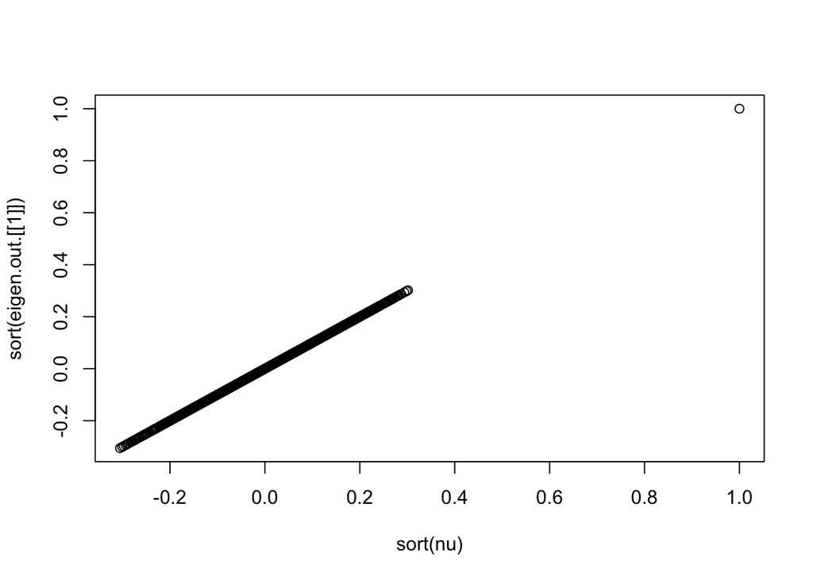

```r
N. <- solve(D.half) %*% A %*% solve(D.half)
eigen.out. <- eigen(N.)
plot(sort(nu),sort(eigen.out.[[1]]))
```

固有値の大小順序が異なるので、そろえるために、順序情報を取り出しておく

```r
ord.nu <- order(nu)
ord.nu. <- order(eigen.out.[[1]])
```

固有値の値の順序に関して、$D^{-1/2}AD^{-1/2}$から求めた固有ベクトルに$D^{-1/2}$を作用させたものを求める

```r
E <- eigen.out.[[2]][,ord.nu.]
e.vectors <- solve(D.half) %*% E
```

このようにして算出したベクトルは対応するNの固有ベクトルとなっている（Nを固有値分解して求めた固有ベクトルの定数倍になっている）

```r
range(N %*% e.vectors - t(t(e.vectors) * nu[ord.nu])) # Nx = nu x をすべてのx \in e.vectorsが満たすので0になる
```

```
## [1] -1.212138e-16  8.760354e-17
```

### Normal行列スペクトルの解釈

- 特性関数の解釈は特別な場合を除いて簡単ではないという
- 固有値が保有している情報は、サイクルと木の両方になる

### 隣接行列、ラプラシアン、Normal行列のスペクトルの相互の関係など

隣接行列は、ノードの次数についての補正をしていないので、「ノードの次数がそろっていたらこれこれ」を満足し、そうでないときは、満足しない、という特徴と関連づく。

それに対して、ラプラシアンとNormal行列は隣接行列にノード次数の補正を追加した形をしており、ノード次数が一定でないグラフにもこれこれが言える、というように一般化したスペクトルになっている。

- ラプラシアンはラプラシアン。平衡状態。あるエネルギー状態での波の様子などを表す。
- Normal行列はラプラシアンにノードに次数の重みを付与したものなっている
- Normal 行列はグラフ上の単純なランダムウォークの推移行列
- $N^2$は隣接行列を分割表と見た時の$\chi^2$行列ともみなせる???

## Normal行列とランダムウォーク

$v^T N = new.v^T, N^T v = ew.v$で$N$が確率推移行列であるということは、$N$の行和が1であって、$N$の全成分が0以上だということ

```r
range(apply(N,1,sum)) # 1
```

```
## [1] 1 1
```

```r
range(N) # >=0
```

```
## [1] 0.00000000 0.04545455
```

ランダムウォークをさせてみる。収束する様子が見える

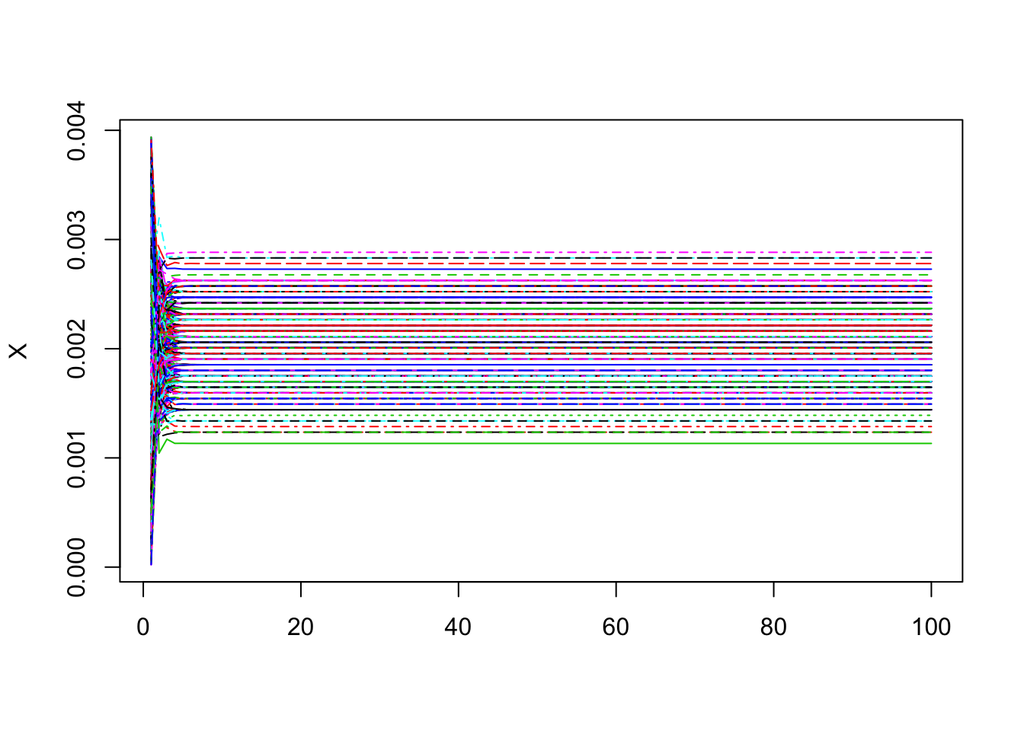

```r
n.iter <- 100
X <- matrix(0,n.iter,length(N[,1]))
X[1,] <- runif(length(X[1,]))
X[1,] <- X[1,]/sum(X[1,])
for(i in 2:n.iter){
  X[i,] <- t(N) %*% X[i-1,]
}
matplot(X,type="l")
```

収束先は、ノードの次数に比例した割合になる。 その値は$N^T \mathbf{1}$のように、全ノードに同じ重みを置いた状態から１歩移動した状態と比例する。

行きつ戻りつの離散性があるので、厳密には定常ではなく、わずかな振動を伴った状態に落ち着く

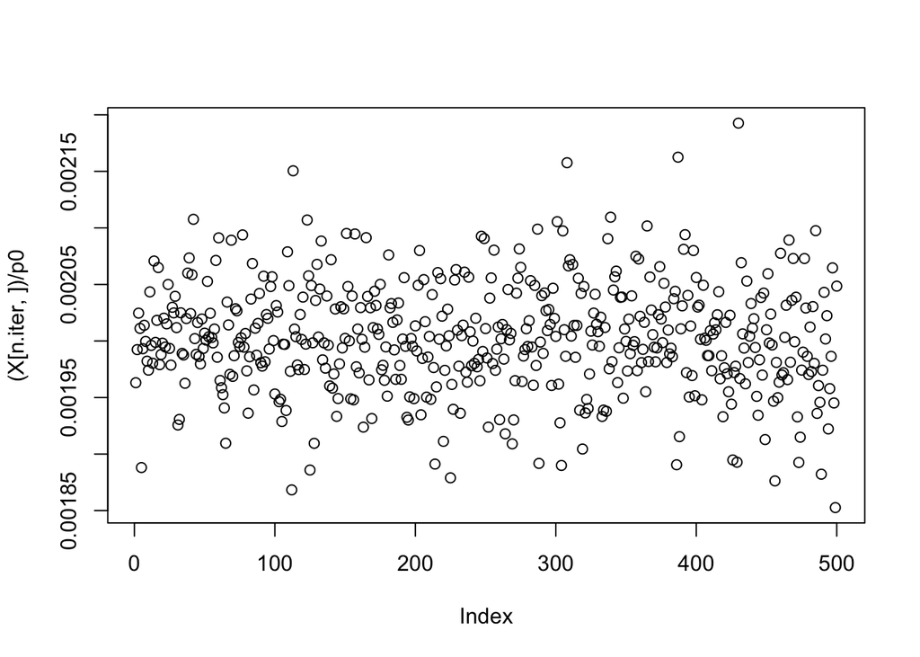

```r
# 均一状態から１歩
p0 <- t(N) %*% rep(1,length(N[,1]))
# 多数歩後と比較
plot((X[n.iter,])/p0)
```

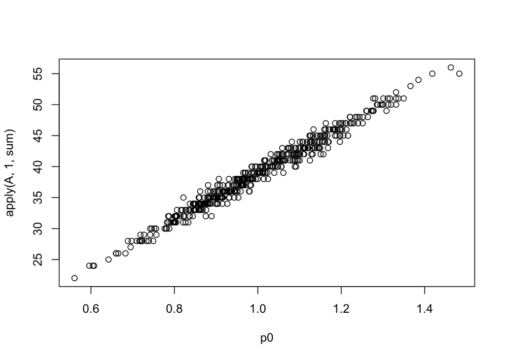

```r
# ノード次数と比較
plot(p0,apply(A,1,sum))
```

この定常状態は第一固有値と関係している。

第二固有値はいかに早くその定常状態に向かって変化するかを表す。 第二固有値が小さいとすぐに収束する。 それは ランダムウォークの迷路が複雑なほど、すぐにたどってきた経路がわからなくなることと関係する。 逆に第二固有値が１に近いとなかなか収束しないが、それは、ラプラシアンの非0の固有値の中に0に近いものが存在することと対応しており、非連結ではないが、非連結に近い状態のグラフであることに対応しており、その場合はには、なかなか収束しない

### $N^2$はAの$\chi^2$行列と関係する

```r
rowsumA <- apply(A,1,sum)
colsumA <- apply(A,2,sum)
expected.mat <- matrix(rowsumA,ncol=1) %*% matrix(colsumA,nrow=1)/sum(A)
# ノード次数を使って以下のようにも計算できる
v.deg <- apply(A,1,sum)
expected.mat2 <- matrix(v.deg,ncol=1) %*% matrix(v.deg,nrow=1)/sum(v.deg)
range(expected.mat - expected.mat2)
```

```
## [1] 0 0
```

$\chi^2$行列であるとは、期待値と実値とから算出されるものなので

```r
chimat <- (A-expected.mat)^2/expected.mat
sum(chimat)
```

```
## [1] 230439.5
```

実際、Aのうち、非0の成分の項は
$$(1-expected)^2/expected=1/expected - 2 + expected$$
となり、値が0の成分の項は
$$(0-expected)^2/expected=expected$$
となる。

$N$に関係する対称行列$N. = D^{-1/2}AD^{-1/2}$のうち、Aの成分が非0の部分について、次のような関係で、Aから作った$\chi^2$値行列と比例関係にある。

補正のために次数の総和を掛けたり、1を引いたり、Aの0成分に相当する$\chi^2$寄与分を考慮したりした結果が比例関係である。

このような関係を使うことで、Aを分割表とみたときの$\chi^2$値(ノード次数の偏り)がNormal行列の固有値と関係づく

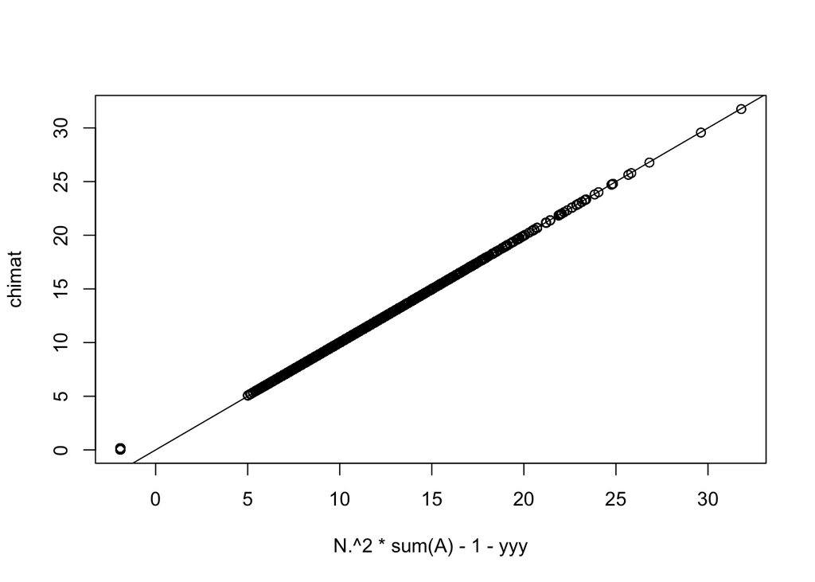

```r
N. <- solve(D.half) %*% A %*% solve(D.half)
zero.elem.term <- chimat[which(A==0)]
yyy <- sum(zero.elem.term)/sum(A)
plot(N.^2 * sum(A)-1-yyy,chimat)
abline(0,1)
```

## グラフの分解

### 隣接行列の場合

#### クロネッカー積

２つのグラフがあったとき、その隣接行列のクロネッカー積も隣接行列になる

小さな２つのグラフでやってみる

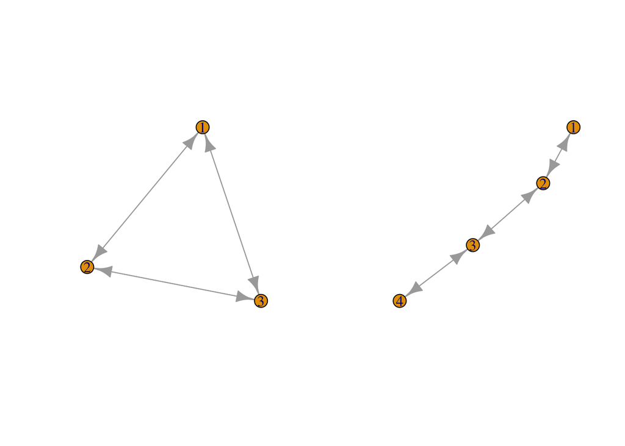

```r
A1 <- rbind(c(0,1,1),c(1,0,1),c(1,1,0))
A2 <- rbind(c(0,1,0,0),c(1,0,1,0),c(0,1,0,1),c(0,0,1,0))
g1 <- graph.adjacency(A1)
g2 <- graph.adjacency(A2)
par(mfcol=c(1,2))
plot(g1)
plot(g2)
```

```r
par(mfcol=c(1,2))
```

隣接行列のクロネッカー積 $A1 \otimes A2$ を計算する

```r
A12 <- A1 %x% A2
A1
```

```
##      [,1] [,2] [,3]
## [1,]    0    1    1
## [2,]    1    0    1
## [3,]    1    1    0
```

```r
A2
```

```
##      [,1] [,2] [,3] [,4]
## [1,]    0    1    0    0
## [2,]    1    0    1    0
## [3,]    0    1    0    1
## [4,]    0    0    1    0
```

```r
A12
```

```
##       [,1] [,2] [,3] [,4] [,5] [,6] [,7] [,8] [,9] [,10] [,11] [,12]
##  [1,]    0    0    0    0    0    1    0    0    0     1     0     0
##  [2,]    0    0    0    0    1    0    1    0    1     0     1     0
##  [3,]    0    0    0    0    0    1    0    1    0     1     0     1
##  [4,]    0    0    0    0    0    0    1    0    0     0     1     0
##  [5,]    0    1    0    0    0    0    0    0    0     1     0     0
##  [6,]    1    0    1    0    0    0    0    0    1     0     1     0
##  [7,]    0    1    0    1    0    0    0    0    0     1     0     1
##  [8,]    0    0    1    0    0    0    0    0    0     0     1     0
##  [9,]    0    1    0    0    0    1    0    0    0     0     0     0
## [10,]    1    0    1    0    1    0    1    0    0     0     0     0
## [11,]    0    1    0    1    0    1    0    1    0     0     0     0
## [12,]    0    0    1    0    0    0    1    0    0     0     0     0
```

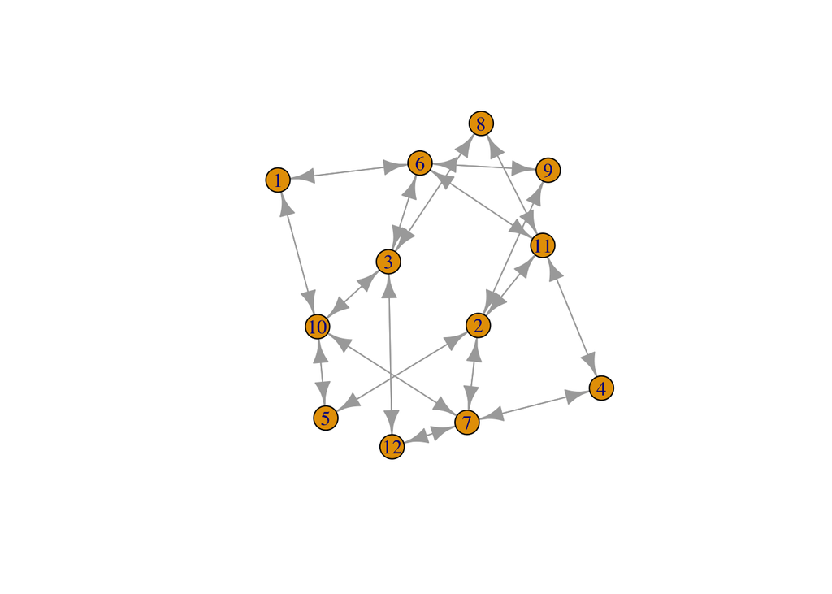

```r
g12 <- graph.adjacency(A12)
plot(g12,shape="circle")
```

まずは、g1,g2,g12の固有値分解をしておく

```r
eigen.out1 <- eigen(A1)
eigen.out2 <- eigen(A2)
eigen.out12 <- eigen(A12)
```

A12の固有値・固有ベクトルの作る行列がA1,A2のそれの総当たりペアの積関係になっている

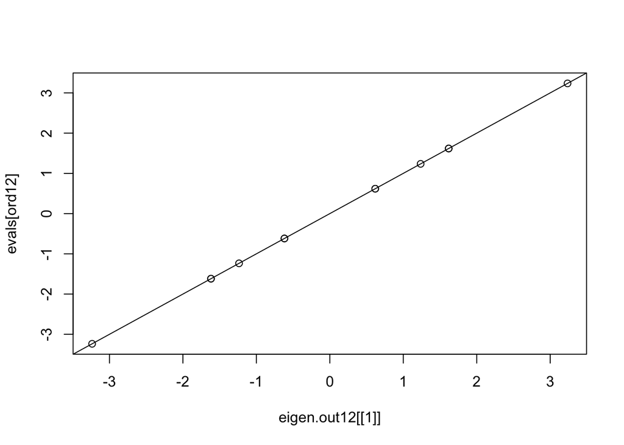

```r
p1 <- 1:length(eigen.out1[[1]])
p2 <- 1:length(eigen.out2[[1]])
p12 <- expand.grid(p1,p2)

evals  <- rep(0,length(p12[,1]))
evecs <- matrix(0,length(p12[,1]),length(p12[,1]))
for(i in 1:length(p12[,1])){
  tmp1 <- eigen.out1[[1]][p12[i,1]]
  tmp2 <- eigen.out2[[1]][p12[i,2]]
  evals[i] <- tmp1 * tmp2 # 固有値ペアの積
  tmp1 <- eigen.out1[[2]][,p12[i,1]]
  tmp2 <- eigen.out2[[2]][,p12[i,2]]
  evecs[,i] <- tmp1 %x% tmp2
}
# 固有値は確かに同じで
ord12 <- order(evals,decreasing=TRUE)
plot(eigen.out12[[1]],evals[ord12])
abline(0,1)
```

```r
# 固有ベクトルは確かに Mx - lambda x =0を満たす
for(i in 1:length(p12[,1])){
  print(range(A12 %*% evecs[,i] - evals[i] * evecs[,i]))
}
```

```
## [1] -8.881784e-16  1.110223e-15
## [1] -6.661338e-16  9.436896e-16
## [1] -4.440892e-16  4.440892e-16
## [1] -2.831069e-15  1.942890e-15
## [1] -1.221245e-15  1.887379e-15
## [1] -1.665335e-15  1.665335e-15
## [1] -6.106227e-16  9.436896e-16
## [1] -6.383782e-16  4.718448e-16
## [1] -5.273559e-16  5.273559e-16
## [1] -5.551115e-15  3.996803e-15
## [1] -2.886580e-15  3.885781e-15
## [1] -3.108624e-15  3.108624e-15
```

#### カルテシアン的な和

$A1 \oplus A2$ というのもある

単位行列を掛ける順番に注意すること。A1には右から、A2には左から掛ける

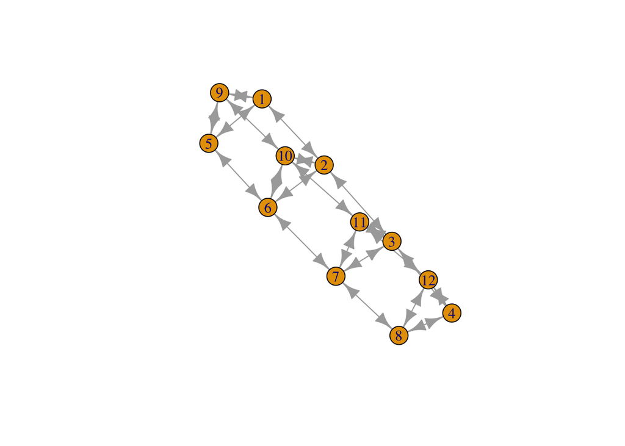

```r
B12 <- A1 %x% diag(rep(1,length(A2[,1]))) + diag(rep(1,length(A1[,1])))  %x% A2
plot(graph.adjacency(B12))
```

```r
eigen.outB12 <- eigen(B12)
```

この場合は、固有ベクトルはクロネッカー積の場合と同じで、固有値は和となる

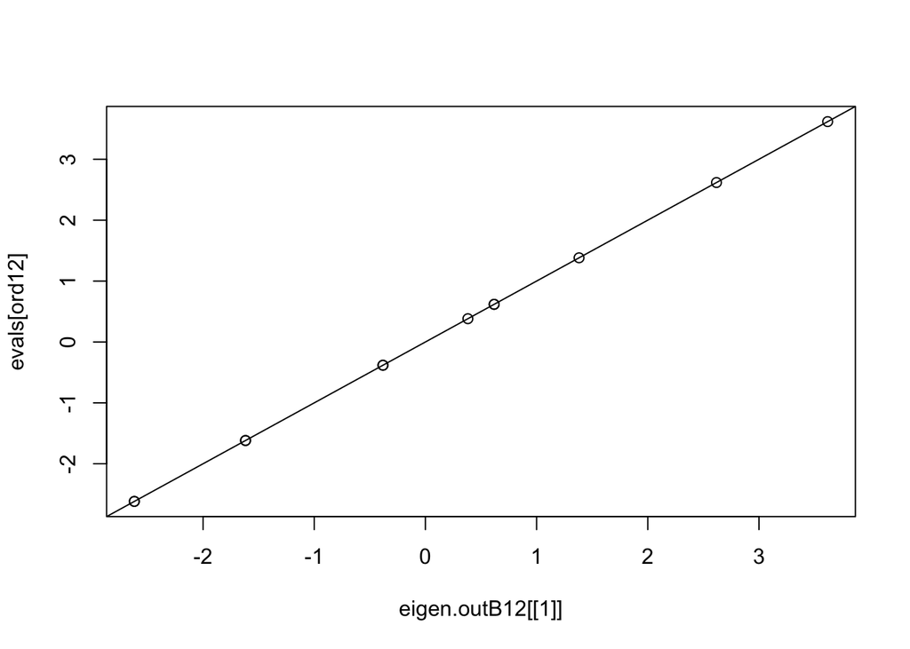

```r
evals  <- rep(0,length(p12[,1]))
evecs <- matrix(0,length(p12[,1]),length(p12[,1]))
for(i in 1:length(p12[,1])){
  tmp1 <- eigen.out1[[1]][p12[i,1]]
  tmp2 <- eigen.out2[[1]][p12[i,2]]
  evals[i] <- tmp1 + tmp2 # 固有値ペアの積でなく、和
  tmp1 <- eigen.out1[[2]][,p12[i,1]]
  tmp2 <- eigen.out2[[2]][,p12[i,2]]
  evecs[,i] <- tmp1 %x% tmp2
}
# 固有値は確かに同じで
ord12 <- order(evals,decreasing=TRUE)
plot(eigen.outB12[[1]],evals[ord12])
abline(0,1)
```

```r
# 固有ベクトルは確かに Mx - lambda x =0を満たす
for(i in 1:length(p12[,1])){
  print(range(B12 %*% evecs[,i] - evals[i] * evecs[,i]))
}
```

```
## [1] -6.661338e-16  4.440892e-16
## [1] -7.216450e-16  6.938894e-16
## [1] -6.106227e-16  6.106227e-16
## [1] -1.443290e-15  9.992007e-16
## [1] -2.123302e-15  1.484923e-15
## [1] -1.734723e-15  1.734723e-15
## [1] -2.220446e-16  3.885781e-16
## [1] -5.551115e-16  7.216450e-16
## [1] -4.996004e-16  4.996004e-16
## [1] -2.581269e-15  2.026157e-15
## [1] -3.774758e-15  2.886580e-15
## [1] -3.108624e-15  3.108624e-15
```

### ラプラシアンの場合

ラプラシアンは行列のカルテシアン和の場合には、隣接行列と同じルールが当てはまる

$A1 \oplus A2 = A12$ に対するラプラシアンと、$A1$に対するラプラシアン $L1$と$A2$に対するラプラシアン$L2$とのカルテシアン和 $L1 \oplus L2$が同じであることにも注意

クロネッカー積はルールが当てはまらない

```r
D1 <- diag(apply(A1,1,sum))
L1 <- D1 - A1
D2 <- diag(apply(A2,1,sum))
L2 <- D2 - A2
D12 <- diag(apply(B12,1,sum))
L12. <- D12 - B12
L12 <- L1 %x% diag(rep(1,length(L2[,1]))) + diag(rep(1,length(L1[,1])))  %x% L2
range(L12. - L12)
```

```
## [1] 0 0
```

```r
eigen.out1 <- eigen(L1)
eigen.out2 <- eigen(L2)
eigen.out12 <- eigen(L12)
```

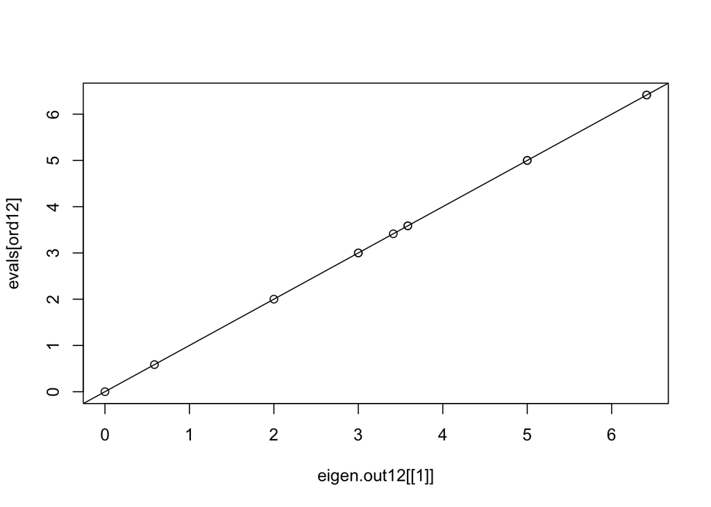

```r
evals  <- rep(0,length(p12[,1]))
evecs <- matrix(0,length(p12[,1]),length(p12[,1]))
for(i in 1:length(p12[,1])){
  tmp1 <- eigen.out1[[1]][p12[i,1]]
  tmp2 <- eigen.out2[[1]][p12[i,2]]
  evals[i] <- tmp1 + tmp2 # 固有値ペアの積でなく、和
  tmp1 <- eigen.out1[[2]][,p12[i,1]]
  tmp2 <- eigen.out2[[2]][,p12[i,2]]
  evecs[,i] <- tmp1 %x% tmp2
}
# 固有値は確かに同じで
ord12 <- order(evals,decreasing=TRUE)
plot(eigen.out12[[1]],evals[ord12])
abline(0,1)
```

```r
# 固有ベクトルは確かに Mx - lambda x =0を満たす
for(i in 1:length(p12[,1])){
  print(range(L12 %*% evecs[,i] - evals[i] * evecs[,i]))
}
```

```
## [1] -3.552714e-15  3.552714e-15
## [1] -2.664535e-15  4.440892e-15
## [1] -1.776357e-15  2.664535e-15
## [1] -1.110223e-15  1.110223e-15
## [1] -8.881784e-16  1.332268e-15
## [1] -1.221245e-15  8.881784e-16
## [1] -1.221245e-15  1.110223e-15
## [1] -8.881784e-16  1.332268e-15
## [1] -1.554312e-15  1.304512e-15
## [1] -4.440892e-16  4.440892e-16
## [1] -4.440892e-16  4.440892e-16
## [1] -1.362633e-15  1.361686e-16
```

ラプラシアンの固有値には0があるので、重複固有値がある

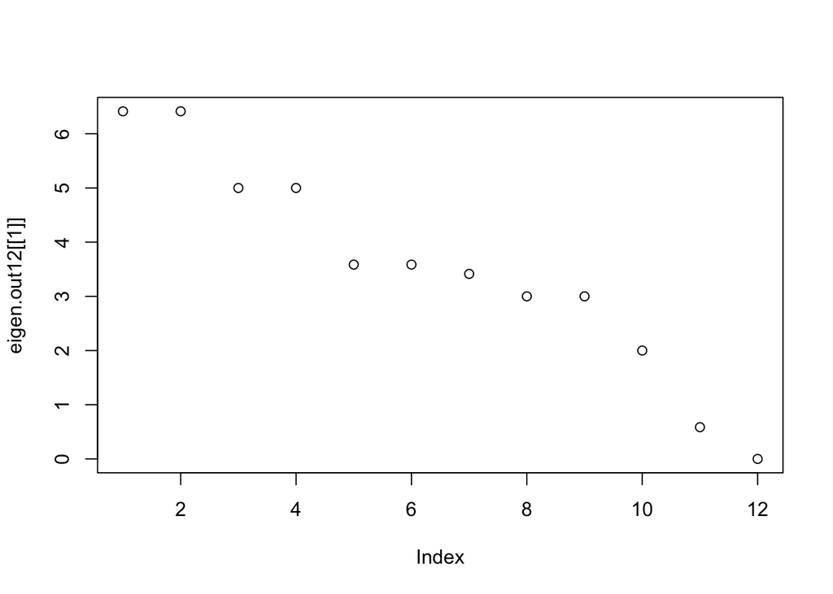

```r
plot(eigen.out12[[1]])
```

また、固有ベクトルも短いベクトルのタンデムな連結のものがある

```r
eigen.out12[[2]]
```

```
##              [,1]        [,2]        [,3]       [,4]        [,5]
##  [1,] -0.02502061 -0.21952108  0.03610759 -0.4066484  0.02713254
##  [2,]  0.06040509  0.52997077 -0.03610759  0.4066484  0.01123867
##  [3,] -0.06040509 -0.52997077 -0.03610759  0.4066484 -0.01123867
##  [4,]  0.02502061  0.21952108  0.03610759 -0.4066484 -0.02713254
##  [5,]  0.20262114  0.08809206  0.33411404  0.2345943  0.44777548
##  [6,] -0.48917070 -0.21267305 -0.33411404 -0.2345943  0.18547468
##  [7,]  0.48917070  0.21267305 -0.33411404 -0.2345943 -0.18547468
##  [8,] -0.20262114 -0.08809206  0.33411404  0.2345943 -0.44777548
##  [9,] -0.17760053  0.13142902 -0.37022163  0.1720541 -0.47490803
## [10,]  0.42876561 -0.31729773  0.37022163 -0.1720541 -0.19671335
## [11,] -0.42876561  0.31729773  0.37022163 -0.1720541  0.19671335
## [12,]  0.17760053 -0.13142902 -0.37022163  0.1720541  0.47490803
##             [,6]       [,7]       [,8]       [,9]      [,10]      [,11]
##  [1,]  0.5327116  0.1562299  0.4004076  0.0796266  0.2886751 -0.3771722
```

[output cut: 24 more lines]

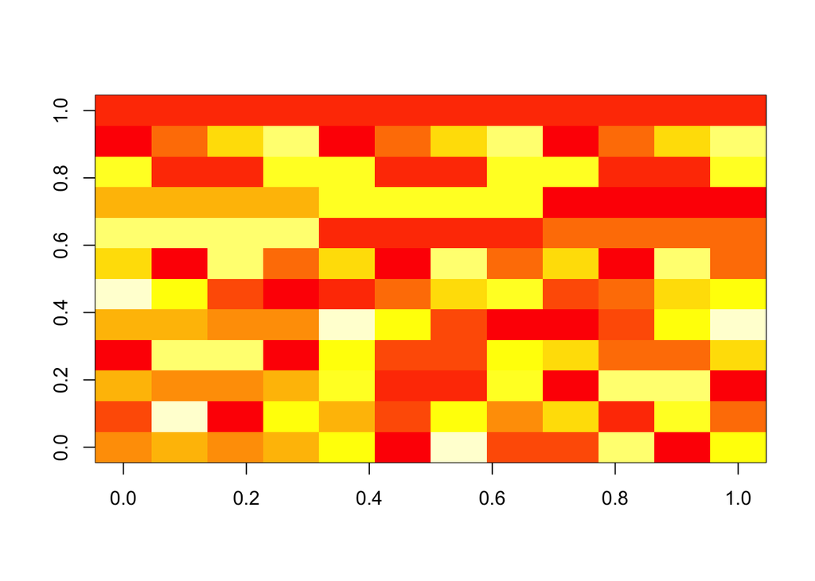

```r
image(eigen.out12[[2]])
```

### Normal 行列の場合

今度は逆に、カルテシアン和はルールに従わないが、クロネッカー積$N1 \otimes N2$は従う

$A1 \oplus A2 = A12$ に対するNormal行列と、$A1$に対するNormal行列$N1$と$A2$に対するNormal行列$N2$とのクロネッカー積 $N1 \otimes N2$が同じであることにも注意

```r
N1 <- solve(D1) %*% A1
N2 <- solve(D2) %*% A2
D12 <- diag(apply(A12,1,sum))
N12 <- N1 %x% N2
N12. <- solve(D12) %*% A12
range(N12- N12.)
```

```
## [1] 0 0
```

```r
eigen.out1 <- eigen(N1)
eigen.out2 <- eigen(N2)
eigen.out12 <- eigen(N12)
```

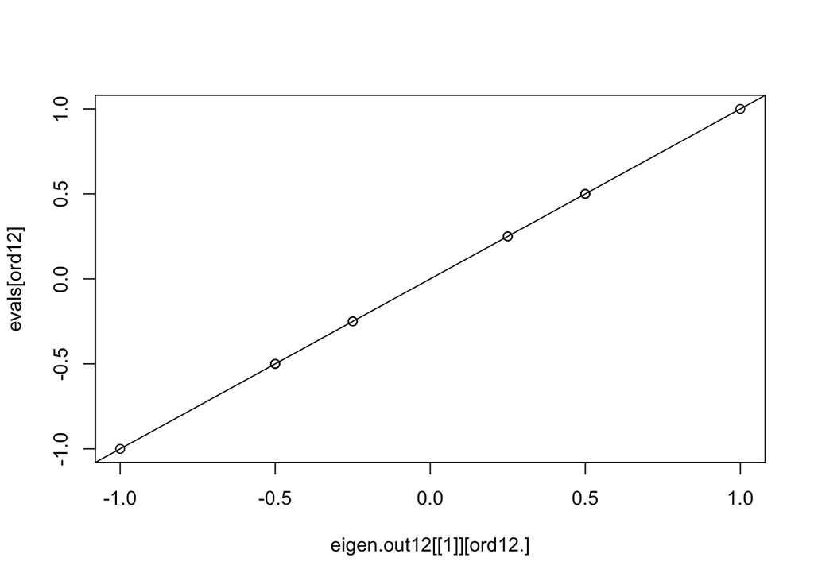

```r
p1 <- 1:length(eigen.out1[[1]])
p2 <- 1:length(eigen.out2[[1]])
p12 <- expand.grid(p1,p2)

evals  <- rep(0,length(p12[,1]))
evecs <- matrix(0,length(p12[,1]),length(p12[,1]))
for(i in 1:length(p12[,1])){
  tmp1 <- eigen.out1[[1]][p12[i,1]]
  tmp2 <- eigen.out2[[1]][p12[i,2]]
  evals[i] <- tmp1 * tmp2 # 固有値ペアの積
  tmp1 <- eigen.out1[[2]][,p12[i,1]]
  tmp2 <- eigen.out2[[2]][,p12[i,2]]
  evecs[,i] <- tmp1 %x% tmp2
}
# 固有値は確かに同じで
ord12 <- order(evals,decreasing=TRUE)
ord12. <- order(eigen.out12[[1]],decreasing=TRUE)
plot(eigen.out12[[1]][ord12.],evals[ord12])
abline(0,1)
```

```r
# 固有ベクトルは確かに Mx - lambda x =0を満たす
for(i in 1:length(p12[,1])){
  print(range(N12 %*% evecs[,i] - evals[i] * evecs[,i]))
}
```

```
## [1] -2.220446e-16  2.220446e-16
## [1] -2.220446e-16  2.498002e-16
## [1] -1.110223e-16  1.110223e-16
## [1] -1.110223e-16  3.330669e-16
## [1] -2.775558e-16  2.636780e-16
## [1] -1.665335e-16  1.665335e-16
## [1] 0.000000e+00 2.220446e-16
## [1] -1.665335e-16  1.665335e-16
## [1] -8.326673e-17  8.326673e-17
## [1] -2.081668e-16  4.440892e-16
## [1] -3.330669e-16  2.498002e-16
## [1] -2.359224e-16  2.359224e-16
```

Normal行列の固有値には必ず１のものがあるので、クロネッカー積の固有値にも重複が見られる

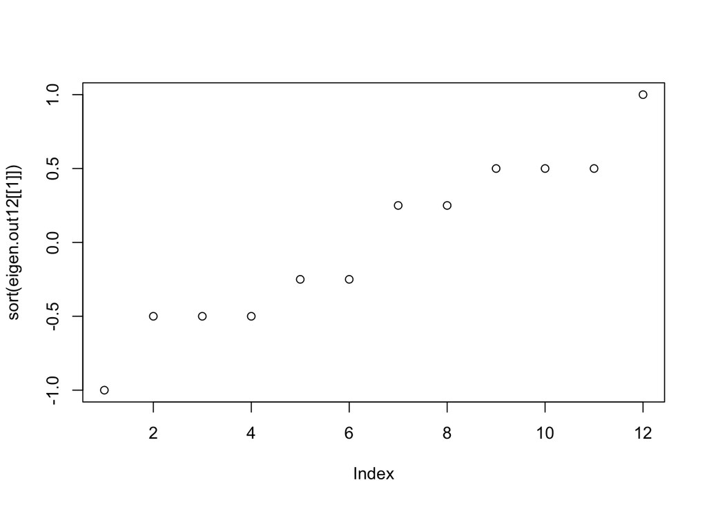

```r
plot(sort(eigen.out12[[1]]))
```

固有ベクトルもタンデムリピートなどからなる

```r
eigen.out12[[2]]
```

```
##            [,1]       [,2]        [,3]        [,4]       [,5]        [,6]
##  [1,] 0.2886751  0.2886751  0.06184544  0.06440213  0.5443311 -0.02951720
##  [2,] 0.2886751 -0.2886751  0.10805984 -0.10865913  0.1360828 -0.38008043
##  [3,] 0.2886751  0.2886751  0.10805984  0.10865913  0.1360828  0.38008043
##  [4,] 0.2886751 -0.2886751  0.06184544 -0.06440213  0.5443311  0.02951720
##  [5,] 0.2886751  0.2886751  0.26589550  0.26642679  0.1360828 -0.49783934
##  [6,] 0.2886751 -0.2886751  0.31210990 -0.31068378 -0.2721655  0.08824171
##  [7,] 0.2886751  0.2886751  0.31210990  0.31068378 -0.2721655 -0.08824171
##  [8,] 0.2886751 -0.2886751  0.26589550 -0.26642679  0.1360828  0.49783934
##  [9,] 0.2886751  0.2886751 -0.42016974 -0.41934291  0.1360828 -0.29183872
## [10,] 0.2886751 -0.2886751 -0.37395534  0.37508591 -0.2721655 -0.11775891
## [11,] 0.2886751  0.2886751 -0.37395534 -0.37508591 -0.2721655  0.11775891
## [12,] 0.2886751 -0.2886751 -0.42016974  0.41934291  0.1360828  0.29183872
##              [,7]       [,8]       [,9]      [,10]        [,11]      [,12]
##  [1,] -0.08385007  0.5443311  0.5163978  0.2136372  0.012612728  0.5163978
##  [2,]  0.36399577 -0.1360828 -0.2581989 -0.1068186  0.006306364  0.2581989
##  [3,]  0.36399577  0.1360828 -0.2581989 -0.1068186 -0.006306364 -0.2581989
##  [4,] -0.08385007 -0.5443311  0.5163978  0.2136372 -0.012612728 -0.5163978
##  [5,] -0.48871185  0.1360828 -0.2581989 -0.5139664 -0.453386546 -0.2581989
##  [6,] -0.04086601  0.2721655  0.1290994  0.2569832 -0.226693273 -0.1290994
##  [7,] -0.04086601 -0.2721655  0.1290994  0.2569832  0.226693273  0.1290994
##  [8,] -0.48871185 -0.1360828 -0.2581989 -0.5139664  0.453386546  0.2581989
##  [9,] -0.32312976  0.1360828 -0.2581989  0.3003293  0.440773818 -0.2581989
## [10,]  0.12471608  0.2721655  0.1290994 -0.1501646  0.220386909 -0.1290994
## [11,]  0.12471608 -0.2721655  0.1290994 -0.1501646 -0.220386909  0.1290994
## [12,] -0.32312976 -0.1360828 -0.2581989  0.3003293 -0.440773818  0.2581989
```

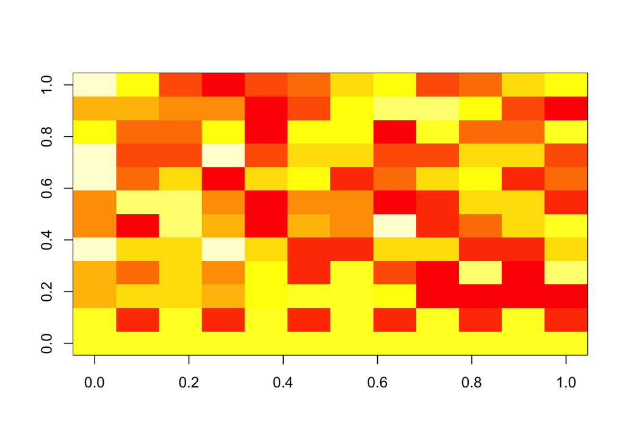

```r
image(eigen.out12[[2]])
```